# Lab3

Author

Shuchen Wu

## Step 1

```r
met <- read.csv("met_all.gz")
```

## Step 2

```r
nrow(met)
```

```
[1] 2377343
```

```r
ncol(met)
```

```
[1] 30
```

We have 2377343 rows and 30 columns here.

## Step 3

```r
str(met)
```

```
'data.frame':   2377343 obs. of  30 variables:
 $ USAFID           : int  690150 690150 690150 690150 690150 690150 690150 690150 690150 690150 ...
 $ WBAN             : int  93121 93121 93121 93121 93121 93121 93121 93121 93121 93121 ...
 $ year             : int  2019 2019 2019 2019 2019 2019 2019 2019 2019 2019 ...
 $ month            : int  8 8 8 8 8 8 8 8 8 8 ...
 $ day              : int  1 1 1 1 1 1 1 1 1 1 ...
 $ hour             : int  0 1 2 3 4 5 6 7 8 9 ...
 $ min              : int  56 56 56 56 56 56 56 56 56 56 ...
 $ lat              : num  34.3 34.3 34.3 34.3 34.3 34.3 34.3 34.3 34.3 34.3 ...
 $ lon              : num  -116 -116 -116 -116 -116 ...
 $ elev             : int  696 696 696 696 696 696 696 696 696 696 ...
 $ wind.dir         : int  220 230 230 210 120 NA 320 10 320 350 ...
 $ wind.dir.qc      : chr  "5" "5" "5" "5" ...
 $ wind.type.code   : chr  "N" "N" "N" "N" ...
 $ wind.sp          : num  5.7 8.2 6.7 5.1 2.1 0 1.5 2.1 2.6 1.5 ...
```

[output cut: 16 more lines]

## Step 4

```r
key_vars <- c("year","day","hour","temp","elev","wind.sp")

summary(met[key_vars])
```

```
      year           day          hour            temp             elev
 Min.   :2019   Min.   : 1   Min.   : 0.00   Min.   :-40.00   Min.   : -13.0
 1st Qu.:2019   1st Qu.: 8   1st Qu.: 5.00   1st Qu.: 19.60   1st Qu.: 101.0
 Median :2019   Median :16   Median :11.00   Median : 23.50   Median : 252.0
 Mean   :2019   Mean   :16   Mean   :11.34   Mean   : 23.59   Mean   : 415.8
 3rd Qu.:2019   3rd Qu.:24   3rd Qu.:17.00   3rd Qu.: 27.80   3rd Qu.: 400.0
 Max.   :2019   Max.   :31   Max.   :23.00   Max.   : 56.00   Max.   :9999.0
                                             NA's   :60089
    wind.sp
 Min.   : 0.00
 1st Qu.: 0.00
 Median : 2.10
 Mean   : 2.46
 3rd Qu.: 3.60
 Max.   :36.00
 NA's   :79693
```

```r
table(met$year, useNA = "ifany")
```

```
   2019
2377343
```

```r
table(met$hour, useNA = "ifany")
```

```
     0      1      2      3      4      5      6      7      8      9     10
 99434  93482  93770  96703 110504 112128 106235 101985 100310 102915 101880
    11     12     13     14     15     16     17     18     19     20     21
100470 103605  97004  96507  97635  94942  94184 100179  94604  94928  96070
    22     23
 94046  93823
```

```r
table(met$elev == 9999, useNA = "ifany")
```

```
  FALSE    TRUE
2376633     710
```

```r
met$elev[met$elev == 9999] <- NA

max_elev <- max(met$elev, na.rm = TRUE)
max_elev
```

```
[1] 4113
```

```r
table(met$temp == -40, useNA = "ifany")
```

```
  FALSE    TRUE    <NA>
2317218      36   60089
```

```r
met2 <- subset(met, !is.na(temp) & temp != -40)
new_min_temp <- min(met2$temp, na.rm = TRUE)
new_min_temp
```

```
[1] -17.2
```

## Step 5

```r
summary(met$elev)
```

```
   Min. 1st Qu.  Median    Mean 3rd Qu.    Max.    NA's
    -13     101     252     413     400    4113     710
```

```r
met2[met2$temp == -17.2, c("lat","lon","elev")]
```

```
           lat    lon elev
1203053 38.767 -104.3 1838
1203055 38.767 -104.3 1838
1203128 38.767 -104.3 1838
1203129 38.767 -104.3 1838
1203222 38.767 -104.3 1838
1203225 38.767 -104.3 1838
```

We examined the elevation range using the summary() function. The minimum elevation in the dataset is -13m, and the maximum elevation is 4113m. According to external sources (e.g., NOAA and Wikipedia lists of US weather station elevations), weather stations in the United States are commonly found from slightly below sea level (e.g., Death Valley at ~-86 m) to over 4,000 m in mountainous regions such as the Rockies. Therefore, the elevation range in our dataset appears reasonable.

The suspicious temperature value of –17.2C was investigated by examining its geographic coordinates. The latitude (38.767) and longitude (–104.3) correspond to a location near Colorado Springs, Colorado, at an elevation of approximately 1838 meters. This region is located at a relatively high altitude, where winter temperatures commonly fall below –15C. Therefore, the –17.2C temperature value appears plausible and does not indicate a data error.

## Step 6

```r
max_elev <- max(met2$elev, na.rm = TRUE)
max_elev
```

```
[1] 4113
```

```r
high_station <- subset(met2, elev == max_elev)
dim(high_station)
```

```
[1] 2117   30
```

```r
summary(high_station$temp)
```

```
   Min. 1st Qu.  Median    Mean 3rd Qu.    Max.
   1.00    6.00    8.00    8.13   10.00   15.00
```

```r
summary(high_station$wind.sp)
```

```
   Min. 1st Qu.  Median    Mean 3rd Qu.    Max.    NA's
  0.000   4.100   6.700   7.245   9.800  21.100     168
```

```r
cor(high_station$temp, high_station$wind.sp, use = "complete.obs")
```

```
[1] -0.09373843
```

```r
cor(high_station$temp, high_station$hour, use = "complete.obs")
```

```
[1] 0.4397261
```

```r
cor(high_station$wind.sp, high_station$hour, use = "complete.obs")
```

```
[1] 0.08807315
```

```r
cor(high_station$temp, high_station$day, use = "complete.obs")
```

```
[1] -0.003857766
```

```r
cor(high_station$wind.sp, high_station$day, use = "complete.obs")
```

```
[1] 0.3643079
```

## Step 7

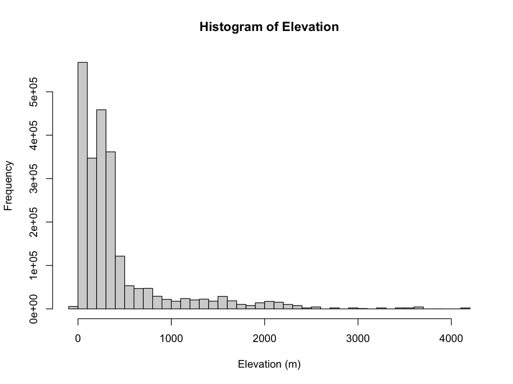

```r
# Elevation
hist(met2$elev, breaks = 50,
     main = "Histogram of Elevation",
     xlab = "Elevation (m)")
```

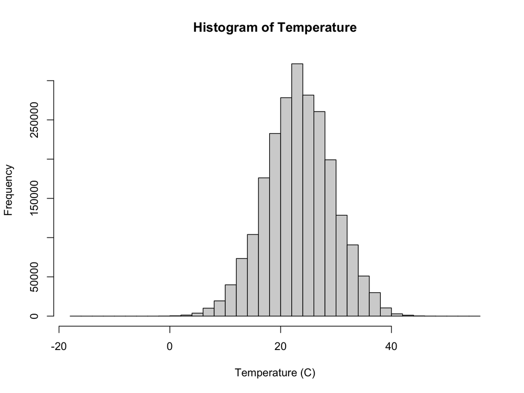

```r
# Temperature
hist(met2$temp, breaks = 50,
     main = "Histogram of Temperature",
     xlab = "Temperature (C)")
```

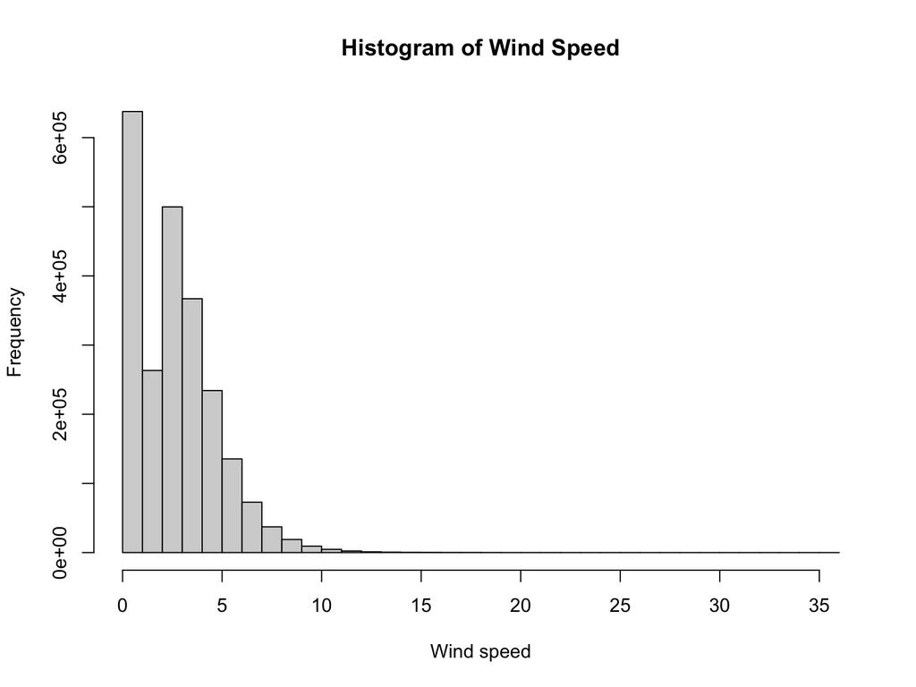

```r
# Wind speed
hist(met2$wind.sp, breaks = 50,
     main = "Histogram of Wind Speed",
     xlab = "Wind speed")
```

```r
# install.packages("leaflet")
library(leaflet)

leaflet(high_station) %>%
  addProviderTiles('OpenStreetMap') %>%
  addCircles(lat=~lat,lng=~lon, opacity=1, fillOpacity=1, radius=100)
```

[interactive chart not shown]

```r
# install.packages("lubridate")
library(lubridate)
high_station$date <- with(high_station, ymd_h(paste(year, month, day, hour, sep= ' ')))

summary(high_station$date)
```

```
                      Min.                    1st Qu.
"2019-08-01 00:00:00.0000" "2019-08-08 11:00:00.0000"
                    Median                       Mean
"2019-08-16 22:00:00.0000" "2019-08-16 14:09:56.8823"
                   3rd Qu.                       Max.
"2019-08-24 11:00:00.0000" "2019-08-31 22:00:00.0000"
```

```r
high_station <- high_station[order(high_station$date), ]

head(high_station)
```

```
       USAFID WBAN year month day hour min  lat      lon elev wind.dir
221697 720385  419 2019     8   1    0  36 39.8 -105.766 4113      170
221698 720385  419 2019     8   1    0  54 39.8 -105.766 4113      100
221699 720385  419 2019     8   1    1  12 39.8 -105.766 4113       90
221700 720385  419 2019     8   1    1  35 39.8 -105.766 4113      110
221701 720385  419 2019     8   1    1  53 39.8 -105.766 4113      120
221702 720385  419 2019     8   1    2  12 39.8 -105.766 4113      120
       wind.dir.qc wind.type.code wind.sp wind.sp.qc ceiling.ht ceiling.ht.qc
221697           5              N     8.8          5       1372             5
221698           5              N     2.6          5       1372             5
221699           5              N     3.1          5       1981             5
221700           5              N     4.1          5       2134             5
221701           5              N     4.6          5       2134             5
221702           5              N     6.2          5      22000             5
       ceiling.ht.method sky.cond vis.dist vis.dist.qc vis.var vis.var.qc temp
```

[output cut: 20 more lines]

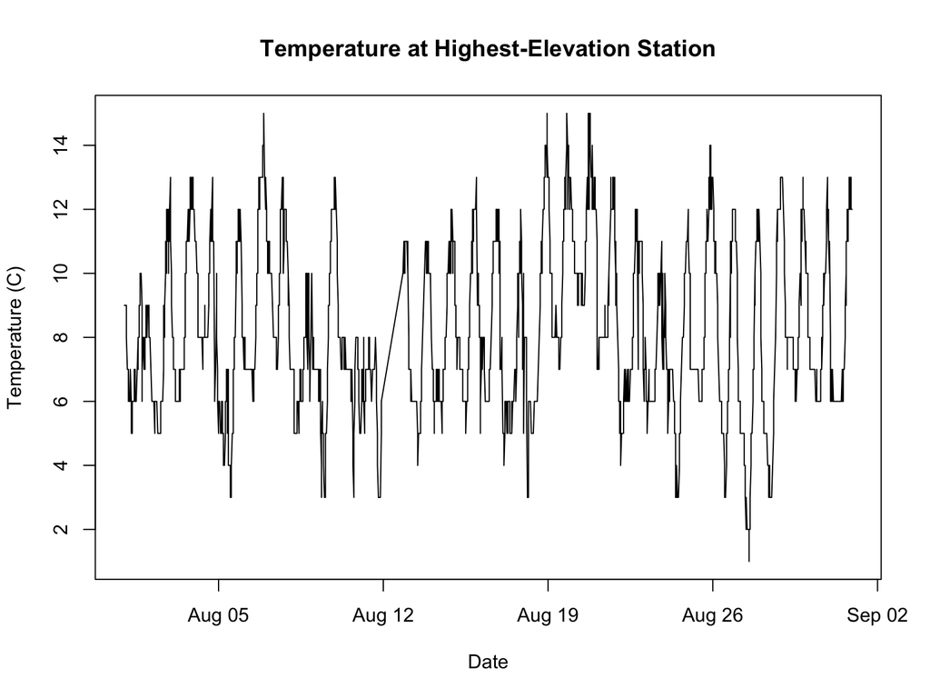

```r
# Temperature time series
plot(high_station$date, high_station$temp, type = "l",
     main = "Temperature at Highest-Elevation Station",
     xlab = "Date", ylab = "Temperature (C)")
```

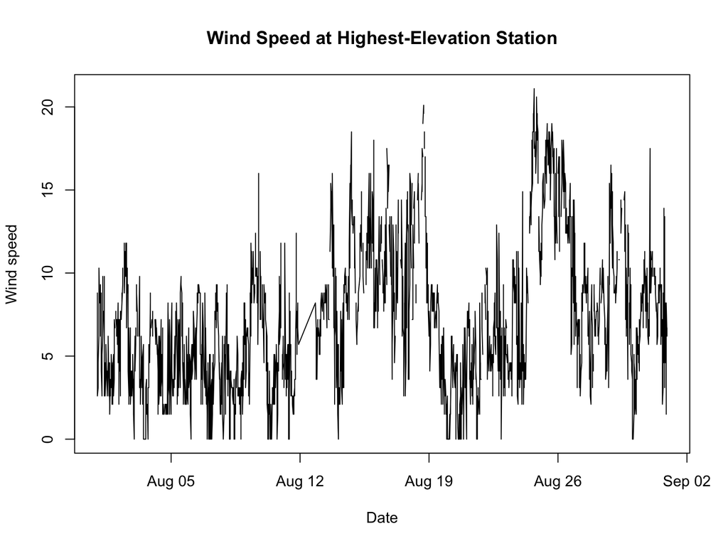

```r
# Wind speed time series
plot(high_station$date, high_station$wind.sp, type = "l",
     main = "Wind Speed at Highest-Elevation Station",
     xlab = "Date", ylab = "Wind speed")
```

The elevation distribution is strongly right-skewed, with most stations at low elevations and a long tail up to the highest station at 4113 m. Temperature appears roughly unimodal and centered around the low-to-mid 23C, while wind speed is also right-skewed with most values near zero and occasional higher speeds. The highest-elevation station is located in the Colorado Rockies, where temperature shows clear short-term (diurnal) fluctuations and wind speed varies more irregularly over time.

## Step 8

Questions about the dataset:

How were temperature and wind speed measurements collected at each station (automatic sensors or manual observations)?

Do all stations use the same instruments and calibration standards?

Would we expect a strong negative relationship between elevation and average temperature across stations?